# Laboratoire 04 - Analyse intégratrice et décision

MQT-2101 - Analyse et modélisation des données

## Pourquoi ça compte

Quelle décision les données peuvent-elles soutenir?

Une analyse utile relie une question, une preuve, une décision et une limite.

## Objectifs du laboratoire

- Choisir une cible continue ou binaire et une référence adaptée.
- Respecter les dates et la disponibilité des informations.
- Communiquer les résultats et une règle de suivi.

## Une direction, deux questions

Voie A

Prévoir les ventes en dollars

Voie B

Repérer un service insuffisant au mois suivant

Un rapport

Une voie principale, l’autre résumée

## Utiliser les informations disponibles

- Une ligne représente un mois et une succursale fictive.
- Pour les ventes, le calendrier est connu; la promotion future peut être incertaine.
- Pour le service du mois suivant, la décision utilise les conditions connues du mois courant.

## Une validation déjà examinée

Les données de 2025 ont déjà été examinées dans les modules 09 et 10. Leur réutilisation ne produit pas un nouveau test indépendant.

## Voie A : même origine et mêmes cibles

- Origine : fin 2024; cibles : les douze mois de 2025.
- Régression avec tendance, mois et succursale.
- Référence : mêmes mois et succursales de 2024.

## Voie A : lire la comparaison

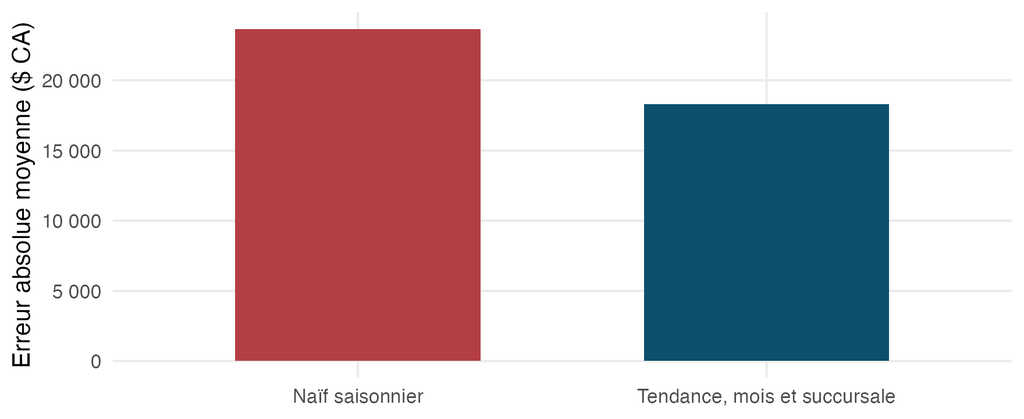

La validation est réutilisée; les mesures sont en dollars.

## Voie B : fixer la règle avant 2025

- Ajuster jusqu’en novembre 2023.
- Fixer le seuil au 80e percentile des probabilités prédites de janvier à novembre 2024.
- Évaluer les erreurs et la proportion ciblée en 2025.

## Voie B : examiner la répartition du ciblage

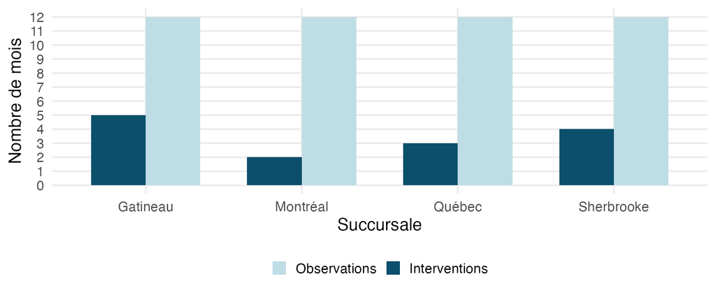

Examinez les effectifs et le contexte de chaque succursale avant d’interpréter cette répartition.

## Un seuil ne garantit pas une capacité

Un seuil calibré sur les scores de 2024 ne garantit pas 20 % d’interventions en 2025. Une capacité stricte exige une règle adaptée au moment des décisions.

## Un résultat nouveau à critiquer

Que ne montre pas une seule mesure?

Dans le guide, traitez la situation fictive de votre voie et justifiez votre réponse dans le même rapport.

## À retenir

Cible

continue ou binaire : des mesures différentes

Comparaison

une méthode et sa référence sur les mêmes observations

Décision

le risque prédit n’est pas l’effet d’une intervention

## Production du laboratoire

Dans un seul rapport Quarto, définissez la décision et la cible, vérifiez les données, développez une voie avec une référence et des mesures adaptées, puis formulez une recommandation avec une limite et un suivi. Résumez l’autre voie en trois phrases. Critiquez aussi les résultats fictifs nouveaux associés à votre voie.

Cette production se réalise une seule fois dans le rapport choisi.

### Auto-vérification

- Je précise la cible, l’origine, l’horizon et l’unité.
- Je compare la méthode et sa référence sur les mêmes observations.
- Je distingue la validation réutilisée d’un nouveau test indépendant.
- Ma recommandation cite les résultats, une limite et une règle de suivi.
- Je justifie ma critique des résultats nouveaux de ma voie.

## Rétroaction et suite

- Demandez une relecture de votre synthèse et corrigez un point précis.
- Vérifiez le rendu et la déclaration IA, si applicable.
- Reprenez l’autre voie ou le transfert pour la révision finale.

## Références et crédits

Hyndman et Athanasopoulos (2021), *Forecasting: Principles and Practice*, 3e édition.

James, Witten, Hastie et Tibshirani (2021), *An Introduction to Statistical Learning*, 2e édition.

Données fictives du cours MQT-2101, Université Laval.